| output: html_document |
| --- |

```r
library(tidyverse)
library(dplyr)
```

## Part 1: Load and check data

1. (1pt) For solving the problems, and answering the questions, create a new rmarkdown document with an appropriate title. created a newmarkdown file
2. (2pt) Load data. How many rows/columns do we have?

```r
gapminder <- read_delim("gapminder.csv")
dim(gapminder)
```

```
## [1] 13055    25
```

3. (2pt) Print a small sample of data. Does it look OK?

```r
gapminder %>%
  sample_n(9)
```

```
## # A tibble: 9 × 25
##   iso3  name  iso2  region sub-r…¹ inter…²  time total…³ ferti…⁴ lifeE…⁵ child…⁶
##   <chr> <chr> <chr> <chr>  <chr>   <chr>   <dbl>   <dbl>   <dbl>   <dbl>   <dbl>
## 1 SDN   Sudan SD    Africa Northe… <NA>     1973  1.13e7    6.92    53.2   153.
## 2 BEL   Belg… BE    Europe Wester… <NA>     1993  1.01e7    1.61    76.3     8.8
## 3 UGA   Ugan… UG    Africa Sub-Sa… Easter…  2009  3.14e7    6.23    56.1    82.1
## 4 PAN   Pana… PA    Ameri… Latin … Centra…  2003  3.21e6    2.68    75.6    24.1
## 5 GRL   Gree… GL    Ameri… Northe… <NA>     1981  5.1 e4    2.33    63.1    NA
## 6 PRT   Port… PT    Europe Southe… <NA>     1978  9.56e6    2.45    70.3    32.3
## 7 MKD   Nort… MK    Europe Southe… <NA>     2005  2.06e6    1.53    74.0    13.7
## 8 LBR   Libe… LR    Africa Sub-Sa… Wester…  2001  2.95e6    5.78    52.2   175.
## 9 ESP   Spain ES    Europe Southe… <NA>     1981  3.78e7    2.04    75.5    13.8
## # … with 14 more variables: youthFemaleLiteracy <dbl>, youthMaleLiteracy <dbl>,
## #   adultLiteracy <dbl>, GDP_PC <dbl>, accessElectricity <dbl>,
## #   agriculturalLand <dbl>, agricultureTractors <dbl>, cerealProduction <dbl>,
## #   fertilizerHa <dbl>, co2 <dbl>, greenhouseGases <dbl>, co2_PC <dbl>,
## #   pm2.5_35 <dbl>, battleDeaths <dbl>, and abbreviated variable names
## #   ¹`sub-region`, ²`intermediate-region`, ³totalPopulation, ⁴fertilityRate,
## #   ⁵lifeExpectancy, ⁶childMortality
```

## Part 2: Descriptive Statistics

1. (3pt) How many countries are there in the dataset? Analyze all three: iso3, iso2 and name

```r
gapminder %>%
  group_by(name) %>%
  filter(!is.na(name)) %>%
  summarise(n = n_distinct(name)) %>%
  arrange(desc(n))
```

```
## # A tibble: 249 × 2
##    name                    n
##    <chr>               <int>
##  1 Afghanistan             1
##  2 Albania                 1
##  3 Algeria                 1
##  4 American Samoa          1
##  5 Andorra                 1
##  6 Angola                  1
##  7 Anguilla                1
##  8 Antarctica              1
##  9 Antigua and Barbuda     1
## 10 Argentina               1
## # … with 239 more rows
```

There are 249 unique country names

```r
gapminder %>%
  group_by(iso2) %>%
  filter(!is.na(iso2)) %>%
  summarise(n=n_distinct(iso2)) %>%
  arrange(desc(n))
```

```
## # A tibble: 248 × 2
##    iso2      n
##    <chr> <int>
##  1 AD        1
##  2 AE        1
##  3 AF        1
##  4 AG        1
##  5 AI        1
##  6 AL        1
##  7 AM        1
##  8 AO        1
##  9 AQ        1
## 10 AR        1
## # … with 238 more rows
```

There are 248 unique country iso2 codes

```r
gapminder %>%
  group_by(iso3) %>%
  filter(!is.na(iso3)) %>%
  summarise(n=n_distinct(iso3)) %>%
  arrange(desc(n))
```

```
## # A tibble: 253 × 2
##    iso3      n
##    <chr> <int>
##  1 ABW       1
##  2 AFG       1
##  3 AGO       1
##  4 AIA       1
##  5 ALA       1
##  6 ALB       1
##  7 AND       1
##  8 ARE       1
##  9 ARG       1
## 10 ARM       1
## # … with 243 more rows
```

There are 253 unique country iso3 codes

2. If you did this correctly, you saw that there are more names than iso-2 codes, and there are even more iso3 -codes. What is going on? Can you find it out?
1. (5pt) Find how many names are there for each iso-2 code. Are there any iso-2 codes that correspond to more than one name? What are these countries?

```r
gapminder %>%
  group_by(name) %>%
  filter(is.na(iso2)) %>%
  summarize(n = n_distinct(iso2)) %>%
  arrange(desc(n))
```

```
## # A tibble: 2 × 2
##   name        n
##   <chr>   <int>
## 1 Namibia     1
## 2 <NA>        1
```

Namibia does not have an iso2 code and there is another country that does not have a country name, just NA

2. (5pt) Now repeat the same for name and iso3-code. Are there country names that have more than one iso3-code? What are these countries? Hint: two of these entitites are CHANISL and NLD CURACAO.

```r
gapminder %>%
  group_by(iso3) %>%
  filter(is.na(name)) %>%
  summarize(n = n_distinct(name)) %>%
  arrange(desc(n))
```

```
## # A tibble: 4 × 2
##   iso3            n
##   <chr>       <int>
## 1 CHANISL         1
## 2 GBM             1
## 3 KOS             1
## 4 NLD_CURACAO     1
```

CHANISL, GBM, KOS, and NLD_CURACAO have iso3 codes but they don't have a name

3. (2pt) What is the minimum and maximum year in these data?

```r
min(gapminder$time, na.rm = TRUE)
```

```
## [1] 1960
```

```r
max(gapminder$time, na.rm = TRUE)
```

```
## [1] 2019
```

1960 is the minimum year and 2019 is the maximum year.

## Part 3: CO2 emissions

1. (2pt) How many missing co2 emissions are there for each year? Analyze both missing CO2 and co2_PC. Which years have most missing data?

```r
gapminder %>%
  filter(is.na(co2_PC), is.na(co2)) %>%
  group_by(time) %>%
  summarise(years = n()) %>%
  arrange(desc(years))
```

```
## # A tibble: 61 × 2
##     time years
##    <dbl> <int>
##  1  2017   217
##  2  2018   217
##  3  2019   217
##  4  1960    60
##  5  1961    60
##  6  1962    58
##  7  1963    57
##  8  1964    51
##  9  1965    51
## 10  1966    51
## # … with 51 more rows
```

2017, 2018, and, 2019 have the most missing co2 emissions.

2. (5pt) Make a plot of total CO2 emissions over time for the U.S, China, and India. Add a few more countries of your choice. Explain what do you see.

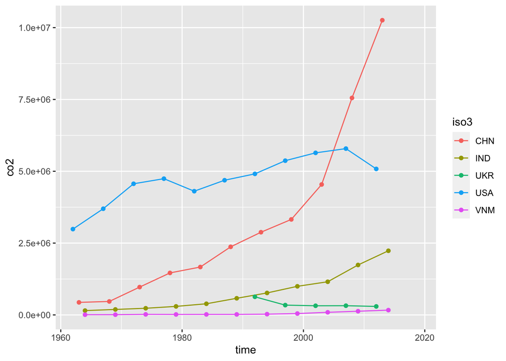

```r
gapminder %>%
  filter(iso3 ==c("USA","CHN","IND","VNM", "UKR")) %>%
  ggplot() +
  geom_line(aes(x=time,y=co2,col=iso3)) +
  geom_point(aes(x=time,y=co2,col=iso3))
```

I notice that countries that are more developed have more CO2 emissions. Countries like Ukraine, Vietnam, and India have less CO2 emissions when compared to the US and China.

3. (5pt) Now let’s analyze the CO2 emissions per capita (co2_PC). Make a similar plot of the same countries. What does this figure suggest?

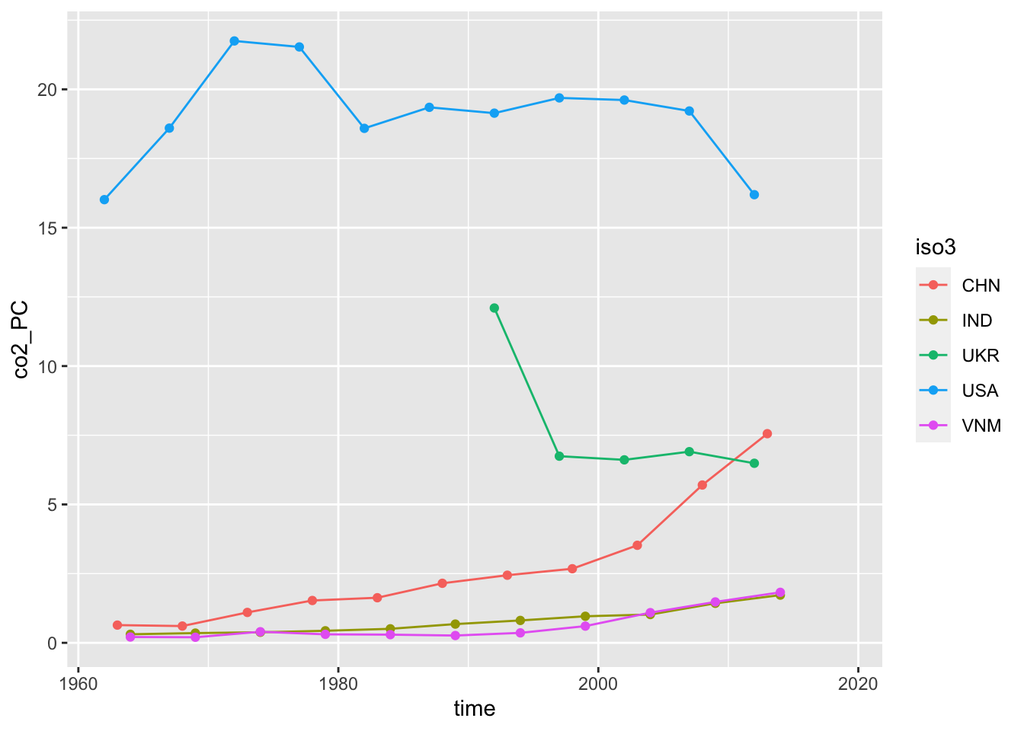

```r
gapminder %>%
  filter(iso3 ==c("USA","CHN","IND","VNM", "UKR")) %>%
  ggplot() +
  geom_line(aes(x=time,y=co2_PC,col=iso3)) +
  geom_point(aes(x=time,y=co2_PC,col=iso3))
```

4. (6pt) Compute average CO2 emissions per capita across the continents (assume region is the same as continent). Comment what do you see Note: just compute averages over countries and ignore the fact that countries are of different size. Hint: Americas 2016 should be 4.80.

Here are the average CO2 emissions per capita in the year 2016.

```r
gapminder %>%
  group_by(region) %>%
  filter(!is.na(co2_PC), !is.na(region), time == 2016) %>%
  summarise(mean = mean(co2_PC)) %>%
  arrange(desc(mean))
```

```
## # A tibble: 5 × 2
##   region    mean
##   <chr>    <dbl>
## 1 Europe    6.64
## 2 Asia      6.47
## 3 Americas  4.80
## 4 Oceania   4.57
## 5 Africa    1.20
```

The average CO2 emissions per capita for all time

```r
gapminder %>%
  group_by(region) %>%
  filter(!is.na(co2_PC), !is.na(region)) %>%
  summarise(mean = mean(co2_PC)) %>%
  arrange(desc(mean))
```

```
## # A tibble: 5 × 2
##   region    mean
##   <chr>    <dbl>
## 1 Europe   7.95
## 2 Americas 6.46
## 3 Asia     6.21
## 4 Oceania  4.39
## 5 Africa   0.930
```

5. (7pt) Make a barplot where you show the previous results–average CO2 emissions per capita across continents in 1960 and 2016.

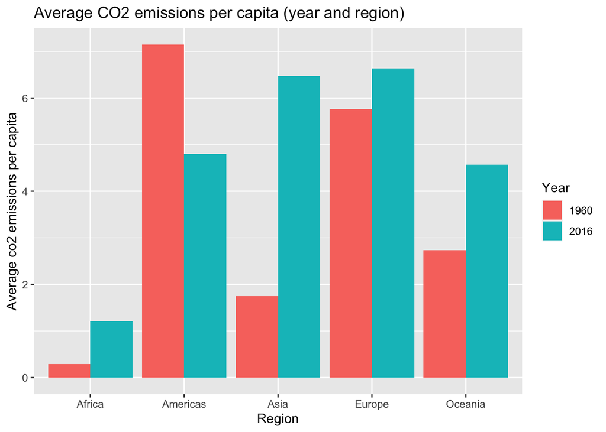

```r
gapminder %>%
  filter(time %in% c(1960, 2016), !is.na(region), !is.na(co2_PC)) %>%
  group_by(time, region) %>%
  summarise(avg_co2PC = mean(co2_PC)) %>%
  ggplot(aes(x=region,y=avg_co2PC, fill=as.factor(time))) +
  geom_col(position = "dodge") +
    labs(title = "Average CO2 emissions per capita (year and region)",
         x="Region",
         y="Average co2 emissions per capita") +
  scale_fill_discrete(name= "Year")
```

6. Which countries are the three largest, and three smallest CO2 emitters (in terms of CO2 per capita) in 2019 for each continent? (Assume region is continent).

I used the 2016 DATA

3 smallest

```r
gapminder %>%
  filter(time == "2016", !is.na(region), !is.na(co2_PC)) %>%
  group_by(region) %>%
  arrange(co2_PC) %>%
  slice_head(n=3) %>%
  select(region, name, co2_PC)
```

```
## # A tibble: 15 × 3
## # Groups:   region [5]
##    region   name                              co2_PC
##    <chr>    <chr>                              <dbl>
##  1 Africa   Congo, Democratic Republic of the 0.0256
##  2 Africa   Somalia                           0.0455
##  3 Africa   Burundi                           0.0472
##  4 Americas Haiti                             0.275
##  5 Americas Nicaragua                         0.887
##  6 Americas Honduras                          1.06
##  7 Asia     Afghanistan                       0.245
##  8 Asia     Nepal                             0.334
##  9 Asia     Yemen                             0.390
## 10 Europe   Liechtenstein                     1.36
## 11 Europe   Albania                           1.58
## 12 Europe   Moldova, Republic of              1.83
## 13 Oceania  Solomon Islands                   0.272
## 14 Oceania  Vanuatu                           0.527
## 15 Oceania  Kiribati                          0.587
```

3 largest

```r
gapminder %>%
  filter(time == "2016", !is.na(region), !is.na(co2_PC)) %>%
  group_by(region) %>%
  arrange(co2_PC) %>%
  slice_tail(n=3) %>%
  select(region, name, co2_PC)
```

```
## # A tibble: 15 × 3
## # Groups:   region [5]
##    region   name                     co2_PC
##    <chr>    <chr>                     <dbl>
##  1 Africa   Seychelles                 6.39
##  2 Africa   Libya                      7.79
##  3 Africa   South Africa               8.48
##  4 Americas Canada                    15.1
##  5 Americas United States of America  15.5
##  6 Americas Trinidad and Tobago       31.8
##  7 Asia     Bahrain                   22.2
##  8 Asia     Kuwait                    25.0
##  9 Asia     Qatar                     38.9
## 10 Europe   Faroe Islands             13.1
## 11 Europe   Luxembourg                15.4
## 12 Europe   Gibraltar                 18.8
## 13 Oceania  Palau                     12.6
## 14 Oceania  Australia                 15.5
## 15 Oceania  New Caledonia             19.3
```

## Part 4: GDP per capita

1. (8pt) Make a scatterplot of GDP per capita versus life expectancy by country, using data for 1960. Make the point size dependent on the country size, and color those according to the continent. Feel free to adjust the plot in other ways to make it better.

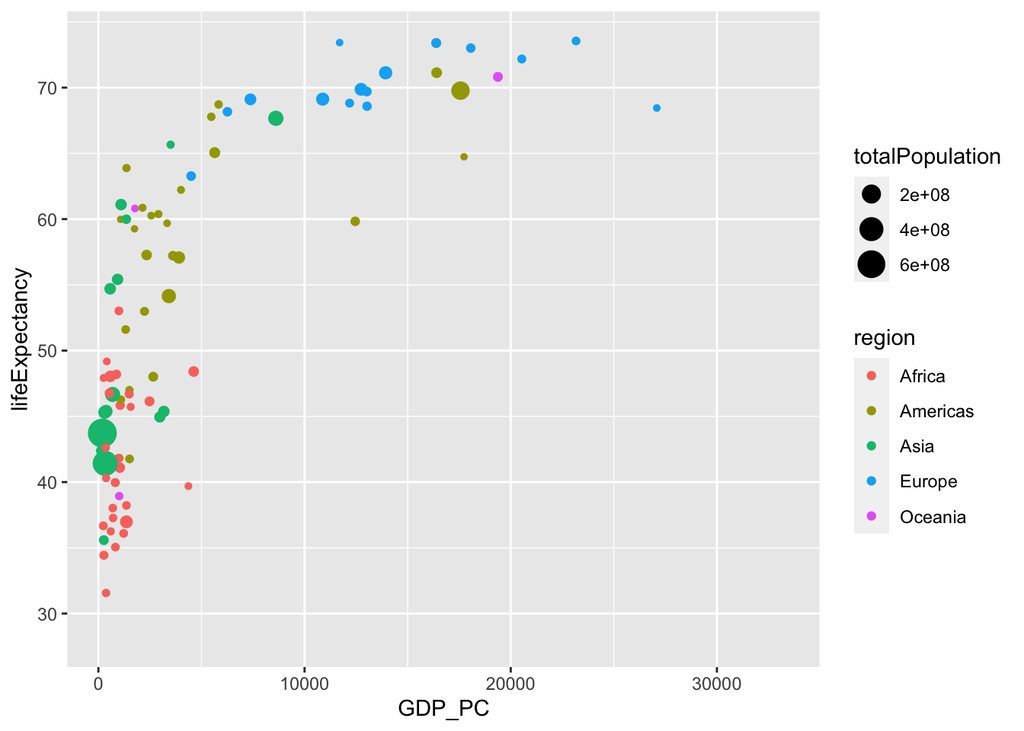

```r
gapminder %>%
  filter(time == 1960, !is.na(region)) %>%
  ggplot(aes(x=GDP_PC,y=lifeExpectancy,col=region,size=totalPopulation)) +
  geom_point()
```

2. (4pt) Make a similar plot, but this time use 2019 data only.

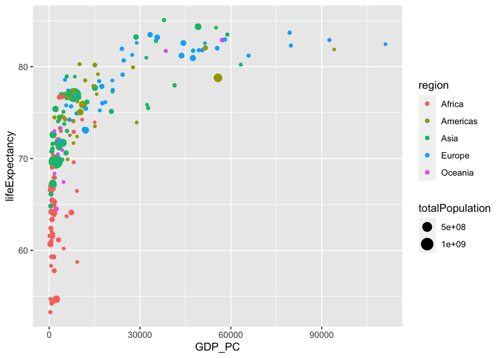

```r
gapminder %>%
  filter(time == 2019, !is.na(region)) %>%
  ggplot(aes(x=GDP_PC,y=lifeExpectancy,col=region,size=totalPopulation)) +
  geom_point()
```

3. (6pt) Compare these two plots and comment what do you see. How has world developed through the last 60 years?

During the last 60 years, all countries' GDP per capita and life expectancy have grown. These factors tend to be linked to some extent, since a higher GDP per capita corresponds to a longer life expectancy. Yet, the rewards on GDP per capita and life expectancy are falling.

4. (6pt) Compute the average life expectancy for each continent in 1960 and 2019. Do the results fit with what do you see on the figures?

```r
gapminder %>%
  filter(!is.na(region), !is.na(lifeExpectancy), !is.na(time)) %>%
  filter(time %in% c("1960","2019")) %>%
  group_by(region, time) %>%
  summarize(average = mean(lifeExpectancy))
```

```
## # A tibble: 10 × 3
## # Groups:   region [5]
##    region    time average
##    <chr>    <dbl>   <dbl>
##  1 Africa    1960    41.5
##  2 Africa    2019    64.1
##  3 Americas  1960    58.6
##  4 Americas  2019    75.8
##  5 Asia      1960    51.6
##  6 Asia      2019    74.6
##  7 Europe    1960    68.3
##  8 Europe    2019    79.4
##  9 Oceania   1960    56.4
## 10 Oceania   2019    73.5
```

Yeah, the findings in terms of life expectancy typically agree with the nations from the regions.

5. (8pt) Compute the average LE growth from 1960-2019 across the continents. Show the results in the order of growth. Explain what do you see.

```r
gapminder %>%
  filter(!is.na(region), !is.na(lifeExpectancy), !is.na(time)) %>%
  filter(time %in% c("1960","2019")) %>%
  group_by(region, time) %>%
  summarize(average = mean(lifeExpectancy)) %>%
  mutate(prev = lag(average), growth = average - prev) %>%
  filter(!is.na(growth)) %>%
  arrange(desc(growth))
```

```
## # A tibble: 5 × 5
## # Groups:   region [5]
##   region    time average  prev growth
##   <chr>    <dbl>   <dbl> <dbl>  <dbl>
## 1 Asia      2019    74.6  51.6   23.0
## 2 Africa    2019    64.1  41.5   22.6
## 3 Americas  2019    75.8  58.6   17.2
## 4 Oceania   2019    73.5  56.4   17.1
## 5 Europe    2019    79.4  68.3   11.1
```

Continents with a large number of developing nations have experienced a bigger increase in life expectancy, whereas continents with a large number of industrialized countries have seen a smaller increase in life expectancy. Several African and Asian countries, for example, are still underdeveloped, contributing to the region's high growth in life expectancy, whereas European countries have been developed for a long time, as seen by their low increase in life expectancy.

6. (6pt) Show the histogram of GDP per capita for years of 1960 and 2019. Try to put both histograms on the same graph, see how well you can do it!

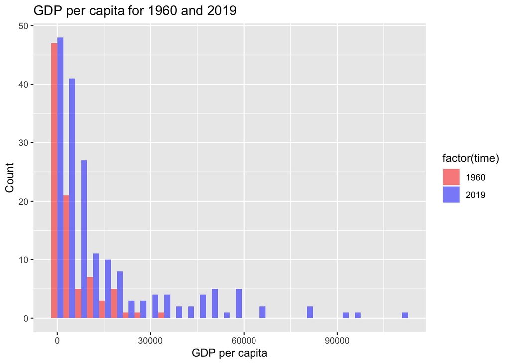

```r
gapminder %>%
  filter(time %in% c(1960, 2019), !is.na(GDP_PC)) %>%
  ggplot(aes(x=GDP_PC, fill = factor(time))) +
  geom_histogram(alpha = 0.5, position = "dodge", bins = 30) +
  scale_fill_manual(values = c("red", "blue"), labels = c("1960" , "2019")) +
  labs(x = "GDP per capita", y= "Count", title = "GDP per capita for 1960 and 2019")
```

7. (6pt) What was the ranking of US in terms of life expectancy in 1960 and in 2019? (When counting from top.) Hint: check out the function rank()! Hint2: 17 for 1960.

1960 life expectancy rank

```r
gapminder %>%
  filter(time == "1960", !is.na(lifeExpectancy), !is.na(region)) %>%
  mutate(rank = rank(-lifeExpectancy)) %>%
  filter(name == "United States of America") %>%
  select(rank)
```

```
## # A tibble: 1 × 1
##    rank
##   <dbl>
## 1    17
```

2019 life expectancy rank

```r
gapminder %>%
  filter(time == "2019", !is.na(lifeExpectancy), !is.na(region)) %>%
  mutate(rank = rank(-lifeExpectancy)) %>%
  filter(name == "United States of America") %>%
  select(rank)
```

```
## # A tibble: 1 × 1
##    rank
##   <dbl>
## 1    46
```

8. (6pt) If you did this correctly, then you noticed that US ranking has been falling quite a bit. But we also have more countries in 2019–what about the relative rank divided by the corresponding number of countries that have LE data in the corresponding year? Hint: 0.0904 for 1960.

1960 relative rank

```r
gapminder %>%
  filter(!is.na(lifeExpectancy), time == "1960", !is.na(region)) %>%
  mutate(rank = rank(-lifeExpectancy), number_country = n(), relativerank = rank/number_country) %>%
  select(name, rank, number_country, relativerank) %>%
  filter(name == "United States of America") %>%
  select(relativerank)
```

```
## # A tibble: 1 × 1
##   relativerank
##          <dbl>
## 1       0.0904
```

2019 relative rank

```r
gapminder %>%
  filter(!is.na(lifeExpectancy), time == "2019", !is.na(region)) %>%
  mutate(rank = rank(-lifeExpectancy), number_country = n(), relativerank = rank/number_country) %>%
  select(name, rank, number_country, relativerank) %>%
  filter(name == "United States of America") %>%
  select(relativerank)
```

```
## # A tibble: 1 × 1
##   relativerank
##          <dbl>
## 1        0.235
```

Finally tell us how many hours did you spend on this PS. I spent 12 hours on this problem set